## 2017 Demographics for Data Carpentry Learners

**Revised:** 2018-02-28  
**Lead:** [Kari L. Jordan](https://github.com/kariljordan), Director of Assessment and Community Equity

# First-Time Learners

**Is this your first time in a Data Carpentry workshop as a learner?**

[output not shown]

**Which of the following describes your current status?**

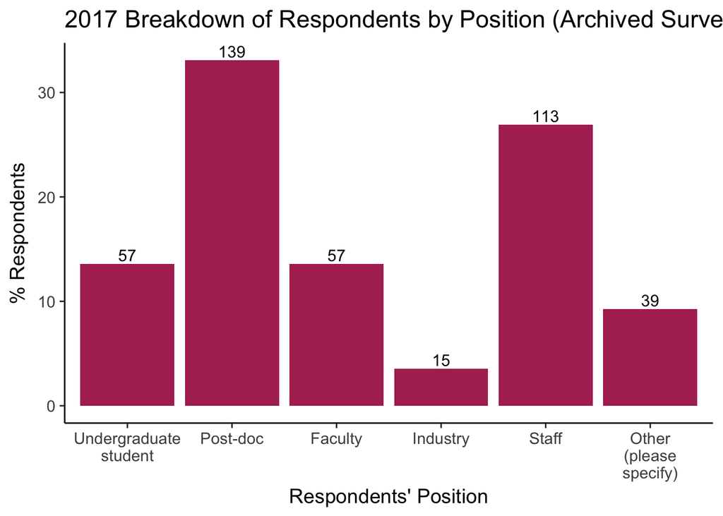

# Domain

**What is your domain of research/study?**

| Domain | n | perc |
| --- | --- | --- |
| Life science (biology, genetics) | 301 | 37 |
| Other (please specify) | 128 | 16 |
| Life science (ecology, zoology, botany) | 77 | 9 |
| Humanities | 43 | 5 |
| Earth sciences (geology, oceanography, meterorology) | 40 | 5 |
| Engineering (civil, mechanical, chemical) | 38 | 5 |
| Physics | 29 | 4 |
| Brain and neurosciencse | 28 | 3 |
| Chemistry | 24 | 3 |
| Medicine | 22 | 3 |
| Computer science and electrical engineering | 21 | 3 |
| Economics | 20 | 2 |
| Statistics | 17 | 2 |
| Public health | 11 | 1 |
| Administration | 9 | 1 |
| Tech support, lab tech, or support programmer | 7 | 1 |
| Space sciences | 3 | 0 |

| Domain-Other | n | perc |
| --- | --- | --- |
| Social Sciences | 9 | 7 |
| Environmental Sciences | 6 | 5 |
| Mathematics | 6 | 5 |
| Library | 4 | 3 |
| Library Science | 4 | 3 |
| Soil Science | 4 | 3 |
| Bioinformatics | 3 | 2 |
| Immunology | 3 | 2 |
| Information Science | 3 | 2 |
| Sociology | 3 | 2 |
| Accounting | 2 | 2 |
| Banking | 2 | 2 |
| Cancer Immunology | 2 | 2 |
| Education | 2 | 2 |
| Finance | 2 | 2 |
| GIS | 2 | 2 |
| IT | 2 | 2 |
| Librarian | 2 | 2 |
| Materials Science | 2 | 2 |
| Microbiology | 2 | 2 |
| Pharmacoepidemiology | 2 | 2 |
| Pharmacy | 2 | 2 |
| Plant Science | 2 | 2 |
| Psychology | 2 | 2 |
| Agricultural Science | 1 | 1 |
| Agroecology | 1 | 1 |
| Animal Nutrition | 1 | 1 |
| Applied Climatology | 1 | 1 |
| Aquaculture | 1 | 1 |
| Biochemistry | 1 | 1 |
| Bioengineering | 1 | 1 |
| Biological Modeling | 1 | 1 |
| Biological Oceanography | 1 | 1 |
| Biomedical Engineering | 1 | 1 |
| Biomedical Science | 1 | 1 |
| BioRenewables | 1 | 1 |
| Biotechnology | 1 | 1 |
| Chemical Biology | 1 | 1 |
| Communications | 1 | 1 |
| Computational Biology | 1 | 1 |
| Cultural Preservation | 1 | 1 |
| Data Library | 1 | 1 |
| Data Management | 1 | 1 |
| Dynamical Systems | 1 | 1 |
| Ecology | 1 | 1 |
| Economic History | 1 | 1 |
| Ecosystem biogeochemistry | 1 | 1 |
| Food Science | 1 | 1 |
| Generalist | 1 | 1 |
| Genetics | 1 | 1 |
| Health Sciences | 1 | 1 |
| Healthcare Informatics | 1 | 1 |
| Higher Education | 1 | 1 |
| Human Factors and Ergonomics | 1 | 1 |
| Human Immunology | 1 | 1 |
| Indigenous Knowledge Systems | 1 | 1 |
| labor relations | 1 | 1 |
| Law | 1 | 1 |
| Marine Science | 1 | 1 |
| Marketing | 1 | 1 |
| materials | 1 | 1 |
| Medicine | 1 | 1 |
| MIS | 1 | 1 |
| Molecular Biology | 1 | 1 |
| Neurology | 1 | 1 |
| Neuroscience | 1 | 1 |
| Political Science | 1 | 1 |
| Pure Mathematics | 1 | 1 |
| Radiobiology and Physics | 1 | 1 |
| Regional Planning | 1 | 1 |
| Remote Sensing | 1 | 1 |
| Risk Management | 1 | 1 |
| Stacks Management | 1 | 1 |
| Transportation Planning | 1 | 1 |
| Urban Planning | 1 | 1 |
| Veterinary Science | 1 | 1 |
| Water Quality | 1 | 1 |

# Gender Identity (U.S. Data Only)

**What is your gender?**

| Gender | n | perc |
| --- | --- | --- |
| Female | 360 | 60 |
| Male | 234 | 39 |
| Prefer not to say | 11 | 2 |

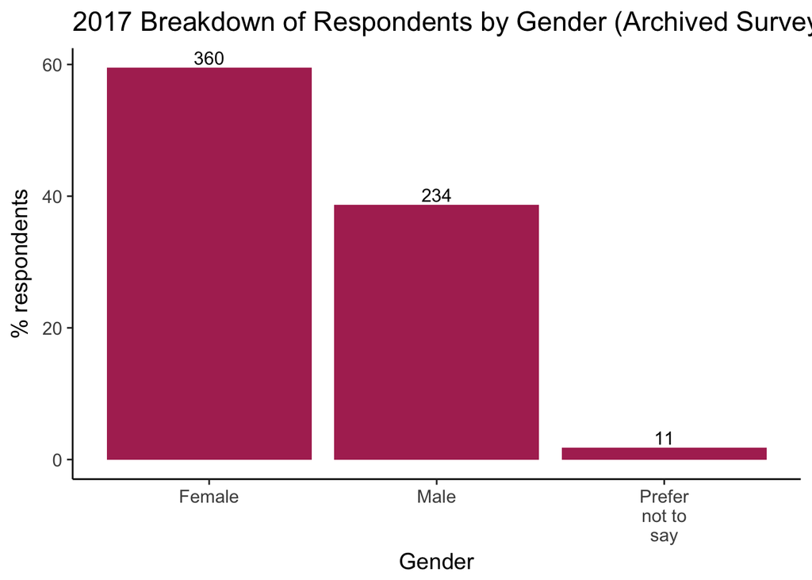

# Racial/Ethnic Identity (U.S. Data Only)

Per various international laws, we are only allowed to collect race/ethnicity information for learners attending workshops in the United States.

**Which race/ethnicity best describes you? (Please choose only one.)**

| Race-Ethnicity | n | perc |
| --- | --- | --- |
| Prefer not to say | 37 | 39 |
| Black or African American | 31 | 33 |
| Hispanic or Latino | 25 | 27 |
| American Indian or Alaskan Native | 1 | 1 |

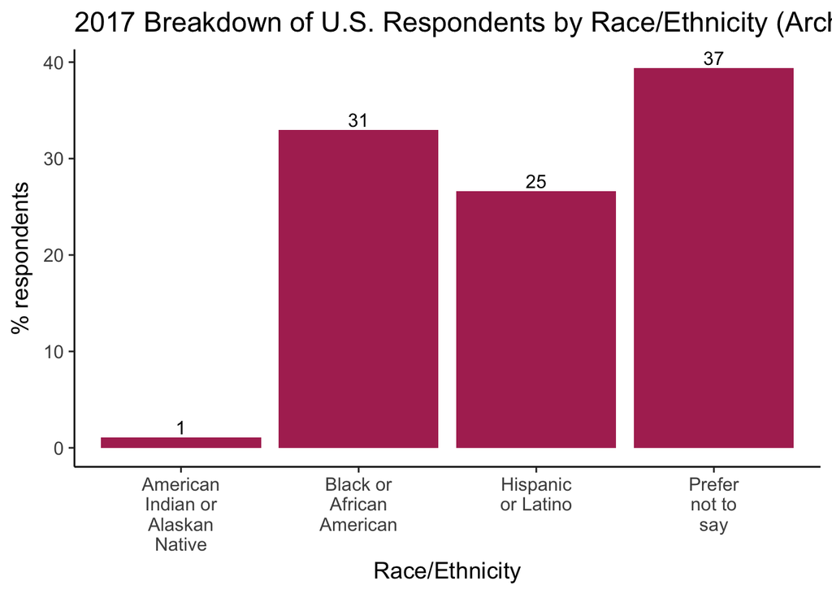

The following includes demographic data for those individuals who took Data Carpentry’s current [pre-workshop survey](https://github.com/carpentries/assessment/blob/master/learner-assessment/surveys/dc_presurvey.pdf) in 2017. There were a total 991 learners who completed this survey in 2017.

# Domain

**Please indicate your relevant fields or disciplines. Check all that apply.**

| Domain | n | % |
| --- | --- | --- |
| Life Sciences | 268 | 34.3 |
| Agricultural or Environmental Sciences | 202 | 25.9 |
| Bioinformatics/Genomics | 156 | 20.0 |
| Biomedical/Health Sciences | 156 | 20.0 |
| Social Sciences | 93 | 11.9 |
| Mathematics or Statistics | 70 | 9.0 |
| Engineering | 68 | 8.7 |
| Earth Sciences | 64 | 8.2 |
| Computer Science | 55 | 7.0 |
| Humanities | 45 | 5.8 |
| Business/Economics | 41 | 5.2 |
| Physical Sciences | 34 | 4.4 |
| Library Sciences | 24 | 3.1 |

# Position

**What is your current position?**

| Position | n | % |
| --- | --- | --- |
| Graduate Student | 457 | 57.7 |
| Research Staff | 104 | 13.1 |
| Postdoctoral Researcher | 102 | 12.9 |
| Faculty | 69 | 8.7 |
| Government Employee | 42 | 5.3 |
| Undergraduate Student | 29 | 3.7 |
| Industry Employee | 19 | 2.4 |
| Retired/Not Employed | 16 | 2.0 |
| Management/Administrator | 11 | 1.4 |

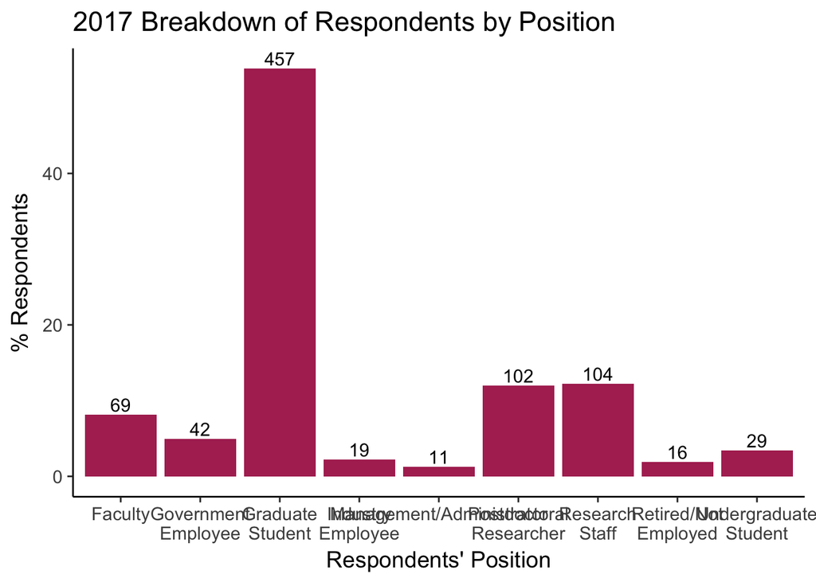

# Exposure to Data Carpentry

**How did you find out about this workshop? Check all that apply.**

| Exposure | n | perc |
| --- | --- | --- |
| Received an email about the workshop | 560 | 57 |
| My friend/colleague told me about it | 215 | 22 |
| My advisor/supervisor told me about it | 143 | 14 |
| Read about it in a newsletter or university web site | 50 | 5 |
| Twitter or other social media | 12 | 1 |
| Other web site | 11 | 1 |

# Gender Identity (U.S. Data Only)

Per various international laws, we are only allowed to collect gender identity information for learners attending workshops in the United States.

**With what gender do you most identify?**

| Gender | n | perc |
| --- | --- | --- |
| Female | 180 | 60 |
| Male | 117 | 39 |
| Transgender female | 1 | 0 |
| Prefer not to answer | 1 | 0 |

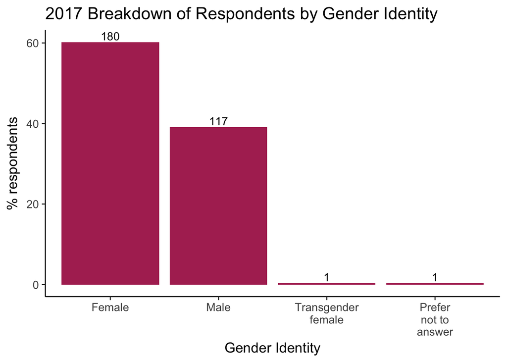

# Racial/Ethnic Identity (U.S. Data Only)

Per various international laws, we are only allowed to collect race/ethnicity information for learners attending workshops in the United States.

**Which race/ethnicity best describes you? (Please choose only one.)**

| Race-Ethnicity | n | % |
| --- | --- | --- |
| White | 181 | 62.0 |
| Asian | 79 | 27.1 |
| Hispanic or Latino(a) | 28 | 9.6 |
| Black or African American | 14 | 4.8 |
| I prefer not to say. | 10 | 3.4 |
| American Indian or Alaska Native | 2 | 0.7 |
| Native Hawaiian or Other Pacific Islander | 1 | 0.3 |

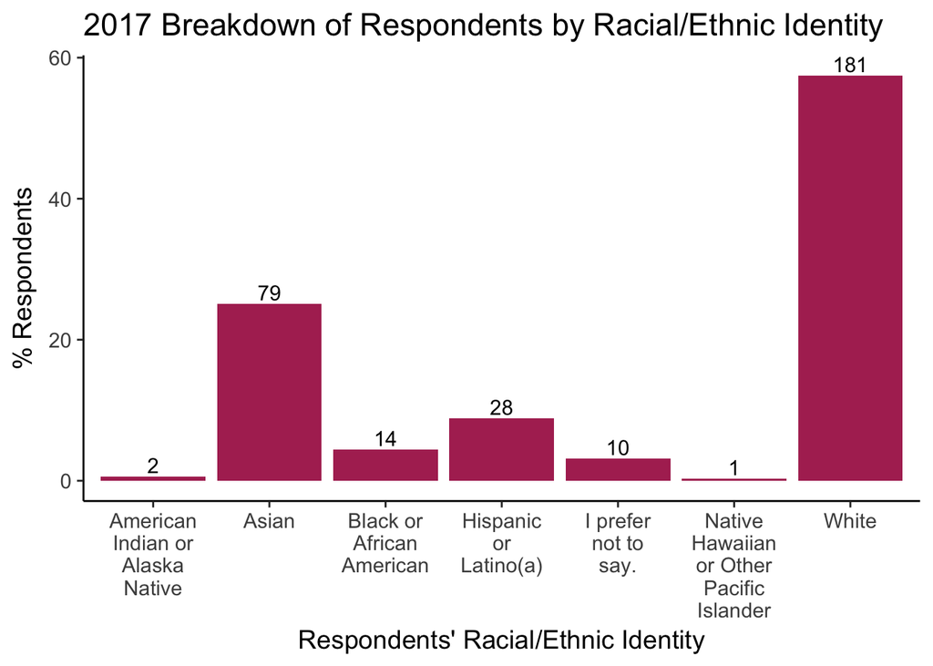